[figure not shown]

### Bayesian Modeling for Socio-Environmental Data

### Dynamic Models: Forecasting Effects of Harvest on Lynx

#### June 01, 2016

### Problem

The Eurasian lynx (*Lynx lynx*) is a medium-sized predator with broad distribution in the boreal forests of Europe and Siberia. The lynx is classified as a threatened species throughout much of its range. In Sweden, there is controversy about legal harvest of lynx. Proponents of harvest argue that allowing hunting of lynx reduces illegal kill (poaching). In contrast, many environmentalists argue that the species is simply too rare to lift its fully protected status. A similar controversy surrounds management of wolves in the Western United States.

Your task is to help resolve this controversy by developing a forecasting model for the abundance of lynx in a management unit in Sweden. You have data on the number of lynx family groups censused in the unit as well as annual records of the number of lynx harvested from the unit. You will model the population using the deterministic model: $N_t=\lambda(N_{t-1}-H_{t-1}).$ where $N_{t}$ is the true, unobserved abundance of lynx and $H_{t-1}$ is the number of lynx harvested during $t-1$ to $t$. The parentheses in this expression reflect the fact that harvest occurs at the beginning of the year, such that the next years population increment comes from the post-harvest population size. (For the population ecologists: What would be the model if harvest occurred immediately before census? Halfway between census points?)  
We can reasonably assume the harvest is measured without error. It may be a bit of a stretch to assume an error-free estimate of $N_t$, but the Swedes have convinced me that their census method, snow tracking, does a very good job of estimating number of family groups (if not the number of lynx) in a management region.

The challenge in this problem is that the observations of lynx abundance (family groups) is not the same as the observation of harvest (number of lynx). Fortunately, you have prior information on the proportional relationship between number of family groups and number of lynx in the population, i.e, $\phi=\frac{f}{N}$ where $f$ is the number of family groups and $N$ is the population size, mean $\phi$=.163 with standard deviation of the mean = .012.

1. Develop a hierarchical Bayesian model (also called a state space model) of the lynx population in the management unit. Diagram the Bayesian network of knowns and unknowns and write out the posterior and factored joint distribution.
2. Write JAGS code to approximate the marginal posterior distribution of the unobserved, true state over time ($\mathbf{N}$), the parameters in the model $\lambda$ and $\phi$ as well as the process variance and observation variance.
3. Check all posterior distributions for convergence.
4. Conduct posterior predictive checks by simulating a new dataset for family groups ($f_t$) at every MCMC iteration. Calculate a Bayesian p value using the sums of squared discrepancy between the observed and the predicted number of family groups based on observed and simulated data, $T^{observed} = \sum_{t=1}^{n}(f_{t}^{observed}-N_{t}\phi)^{2} \\T^{model} = \sum_{t=1}^{n}(f_{t}^{simulated}-N_{t}\phi)^{2}.$ The Bayesian p value is the proportion of MCMC iterations for which $T^{model}>T^{obs}$.
5. Plot the median estimate of the number of lynx family groups over time (1997-2011) including credible intervals. The last 2 years of your plot will be forecasts. Your plot should resemble Figure 1, below. Make a make a forecast two years into the future assuming five harvest levels (0, 10, 25, 50, and 75 animals) during 2010. Environmentalists and hunters have agreed on a acceptable range for lynx abundance in the unit, 26-32 family groups. Estimate the probability that the population is below, within, and above this range for 2011. Tabulate your estimates.

A note about the data. Each row in the data file gives the population estimate for that year in column 2 and that year’s harvest in column 3. Thus the harvest in each row influences the population size in the next row. It follows that you have data on the 2009 harvest that influences the 2010 population, but you do not have census data for 2010. However, decisions are made on the 2010 harvest before the 2010 census data are available.

A couple of hints, ignored at your peril. Use a lognormal distribution to represent uncertainty in the process of change in lynx population size over time. Use a Poisson distribution for the data model relating the true, unobserved state (the total population size) to the observed data (number of family groups). An alternative, which is somewhat more difficult to code, is to model the process as $\text{negative binomia}(N_t|\lambda(N_{t-1}-H_{t-1}, \rho))$ and model the data as $\text{binomial}(y_t|N_t,\phi)$. Explain why this second formulation *might* be better than the formulation you are using. (It turns out they give virtually identical results.)

If you don’t have time to finish the forecasting bit, return to it when you are bored some Sunday afternoon and study the answer code. This is a great tool for population ecologists and wildlife managers, really anyone who needs to evaluate alternatives for policy or management relative to goals for the environment.

### Code

#### Preliminaries

```r
library(rjags)
```

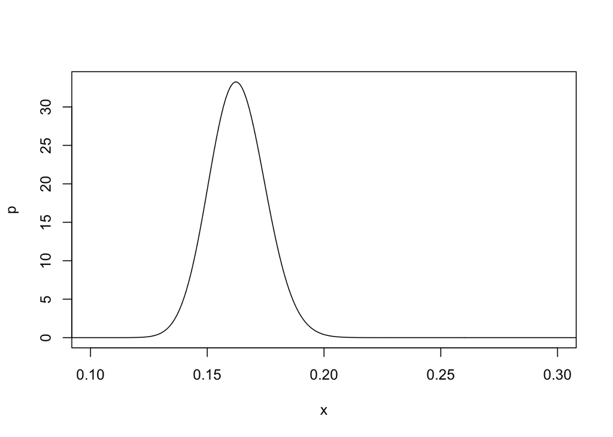

```r
#setwd("/Users/Tom/Documents/Ecological Modeling Course/_A_Master_Lab_Exercises/Dynamic models_lynx_problem/")
y=read.csv("Lynx data.csv")

#Function to get beta shape parameters from moments
shape_from_stats <- function(mu = mu.global, sigma = sigma.global){
         a <-(mu^2-mu^3-mu*sigma^2)/sigma^2
         b <- (mu-2*mu^2+mu^3-sigma^2+mu*sigma^2)/sigma^2
        shape_ps <- c(a,b)
        return(shape_ps)
}

#get parameters for distribution of population multiplier, 1/p
shapes=shape_from_stats(.163,.012)
#check prior on p using simulated data from beta distribution
x = seq(0,1,.001)
p=dbeta(x,shapes[1],shapes[2])
plot(x,p,typ="l",xlim=c(.1,.3))
```

### Simulate data for initial values and model verification

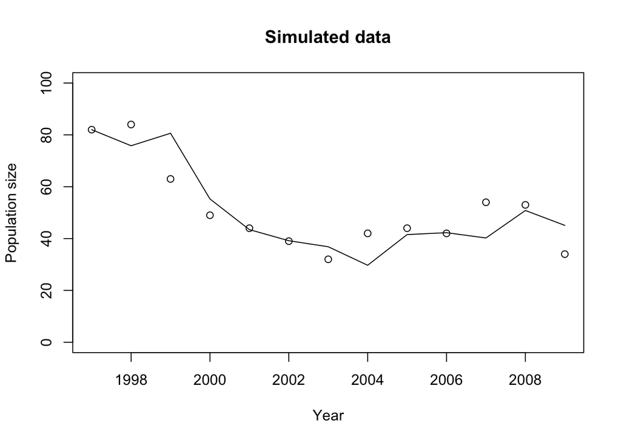

```r
##visually match simulated data with observations for initial conditions
#visually match simulated data with observations for initial conditions
endyr = nrow(y)
n=numeric(endyr+1)
mu=numeric(endyr+1) #use this for family groups
lambda=1.02
sigma.p=.00001
n[1] = y$census[1]

for(t in 2: (endyr+1)){
    n[t] <- lambda*(y$census[t-1] - .16 * y$harvest[t-1])  #use this for family groups
    }
plot(y$yr, y$census,ylim=c(0,100),xlab="Year", ylab="Population size", main="Simulated data")
lines(y$yr,n[1:length(y$yr)])
```

### Initial values and data

```r
# Levels of  Harvest to evaluate relative to goals for forecasting part.
h=c(0, 10, 25, 50, 75)

#Data for JAGS
data = list(
    y.endyr = endyr,
    y.a=shapes[1],
    y.b=shapes[2],
    y.H=y$harvest,
    y=y$census,
    h=h
)

inits = list(
    list(
    lambda = 1.2,
    sigma.p = .01,
    N=n
    ),
    list(
    lambda = 1.01,
    sigma.p = .2,
    N=n*1.2),
    list(
    lambda = .95,
    sigma.p = .5,
    N=n*.5
    ))
```

### Write code in template

```r
{
sink("Lynx Harvest JAGS from cat.R")
cat("
model{
#priors==============
sigma.p ~ dunif(0,5)
tau.p <- 1/sigma.p^2
lambda ~ dunif(0,10)
p ~ dbeta(y.a,y.b)  #Get parameters a and b from mean and sd using moment matching to make this prior informative.  These are calcuated on R side and read in as data.

#Informative priors on initial conditions based on first year's observation of family groups
fg[1] ~ dpois(y[1])
N[1]~dlnorm(log(y[1]/p),tau.p)


#process model===============
for(t in 2:(y.endyr + 1)){  # the last year is a forecast with known harvest data
    mu[t] <- log(max(.0001,lambda*(N[t-1]-y.H[t-1])))
    N[t] ~ dlnorm(mu[t], tau.p)
    fg[t]<-N[t] * p
    }#end of process model

#data model===============
for(t in 2:y.endyr){
        y[t] ~ dpois(p*N[t])
            }  #end of data model

#simulate new data for posterior predicitve check
for(t in 1:y.endyr){
        y.rep[t] ~ dpois(p*N[t])
        #accumlate test statistics for posterior predictive check
        sq[t] <- (y[t]-p*N[t])^2
        sq.rep[t] <-(y.rep[t] - p*N[t])^2
}
#calculate Bayesian P value
fit <- sum(sq[])
fit.new <- sum(sq.rep[])
pvalue <- step(fit.new - fit)

##forecast effects of different harvest regeimes on next year's number of family grops
    for(i in 1:length(h)){
        #mu.hat is the forecast 1 year beyond y.endyr +1, i.e., 2011
        mu.hat[i] <- log(max(.001,lambda*(N[y.endyr+1]-h[i])))
        N.hat[i] ~ dlnorm(mu.hat[i], tau.p) #Nhat forecasts 2 years out
        fg.hat[i] <- N.hat[i] * p
    }


} #end of model

",fill=TRUE)
sink()
}
```

### Compile model, get some summary output, and test for convergence and fit

```r
model = "Lynx Harvest JAGS from cat.R"

n.update=10000
n.iter=50000
n.adapt=5000
n.thin=1

jm = jags.model(model,data=data,inits=inits, n.adapt=n.adapt, n.chains=length(inits))
```

```
##    Graph Size: 242
##
```

```r
update(jm, n.iter=n.update)

z = coda.samples(jm,variable.names=c("lambda","sigma.p","p", "N"), n.iter=n.iter, thin=n.thin)

zj=jags.samples(jm,variable.names=c("N","N.hat", "fg", "fg.hat", "pvalue", "fit", "fit.new"), n.iter=n.iter, thin=n.thin)


#check convergence
heidel.diag(z)
```

```
## [[1]]
##
##         Stationarity start     p-value
##         test         iteration
## N[1]    passed           1     0.3649
## N[2]    passed           1     0.3766
## N[3]    passed       10001     0.0719
## N[4]    passed       10001     0.0817
## N[5]    passed       10001     0.1068
## N[6]    passed       10001     0.0521
## N[7]    failed          NA     0.0435
## N[8]    failed          NA     0.0143
## N[9]    failed          NA     0.0056
## N[10]   failed          NA     0.0115
## N[11]   passed        5001     0.0514
## N[12]   passed       10001     0.0754
## N[13]   failed          NA     0.0106
## N[14]   passed       10001     0.0985
## lambda  passed           1     0.4598
## p       passed       15001     0.0733
## sigma.p passed           1     0.4321
##
##         Halfwidth Mean    Halfwidth
##         test
## N[1]    passed    506.879 2.277091
## N[2]    passed    471.458 1.943761
## N[3]    passed    395.304 1.663280
## N[4]    passed    319.120 1.461930
## N[5]    passed    278.345 1.326417
## N[6]    passed    246.890 1.215149
## N[7]    <NA>           NA       NA
## N[8]    <NA>           NA       NA
## N[9]    <NA>           NA       NA
## N[10]   <NA>           NA       NA
## N[11]   passed    304.073 1.319146
## N[12]   passed    294.439 1.405133
## N[13]   <NA>           NA       NA
## N[14]   passed    197.986 1.173013
## lambda  passed      1.039 0.000899
## p       passed      0.163 0.000591
```

[output cut: 70 more lines]

```
## N[3]    passed    392.477 1.444983
## N[4]    passed    316.722 1.224164
## N[5]    passed    276.397 1.117841
## N[6]    passed    245.047 1.040392
## N[7]    passed    232.706 1.054261
## N[8]    passed    248.847 1.022379
## N[9]    passed    267.356 1.092980
## N[10]   passed    274.966 1.100559
## N[11]   passed    302.353 1.253299
## N[12]   passed    292.019 1.239621
## N[13]   passed    227.149 0.981820
## N[14]   passed    195.555 1.071664
## lambda  passed      1.040 0.000804
## p       passed      0.164 0.000506
## sigma.p passed      0.156 0.002117
```

```r
gelman.diag(z)
```

```
## Potential scale reduction factors:
##
##         Point est. Upper C.I.
## N[1]             1       1.00
## N[2]             1       1.00
## N[3]             1       1.01
## N[4]             1       1.01
## N[5]             1       1.00
## N[6]             1       1.00
## N[7]             1       1.00
## N[8]             1       1.00
## N[9]             1       1.00
## N[10]            1       1.00
## N[11]            1       1.00
## N[12]            1       1.00
## N[13]            1       1.00
## N[14]            1       1.00
## lambda           1       1.00
## p                1       1.01
## sigma.p          1       1.00
##
## Multivariate psrf
##
## 1
```

```r
#remove N from coda object after checking convergence to allow cleaner plotting and summaries
z2 = z[,c("lambda","sigma.p","p"),drop=FALSE]
summary(z2)
```

```
##
## Iterations = 15001:65000
## Thinning interval = 1
## Number of chains = 3
## Sample size per chain = 50000
##
## 1. Empirical mean and standard deviation for each variable,
##    plus standard error of the mean:
##
##           Mean      SD  Naive SE Time-series SE
## lambda  1.0396 0.05437 1.404e-04      0.0002503
## sigma.p 0.1553 0.06720 1.735e-04      0.0006525
## p       0.1640 0.01199 3.096e-05      0.0001533
##
## 2. Quantiles for each variable:
##
##            2.5%    25%    50%    75%  97.5%
## lambda  0.93355 1.0085 1.0381 1.0689 1.1536
## sigma.p 0.05975 0.1082 0.1439 0.1893 0.3181
## p       0.14108 0.1557 0.1637 0.1720 0.1879
```

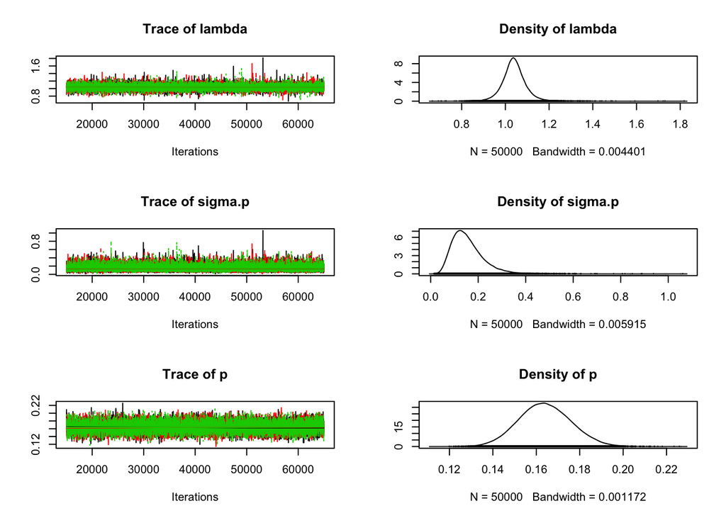

```r
plot(z2)
```

```r
#look at Bayesian P value
zj$pvalue
```

```
## mcarray:
## [1] 0.6112333
##
## Marginalizing over: iteration(50000),chain(3)
```

### Some plots

[figure not shown]

```r
#Do goodness of fit plot.
par(mfrow=c(1,1))
plot(zj$fit.new,zj$fit, xlab = "Discrepancy observed", ylab= "Discrepancy simulated", cex=.05, xlim=c(0,3000), ylim=c(0,3000))
abline(0,1)
p=summary(zj$pvalue,mean)$stat
text(500,2500, paste("Bayesian P value = ", as.character(signif(p,2))))
```

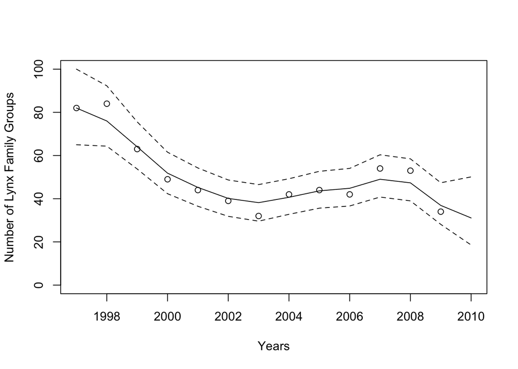

```r
#Plot quantiles of the true, unobserved state vs observations and forecasts.
par(mfrow=c(1,1))
years=seq(1997,2010)
fg = summary(zj$fg,quantile,c(.025,.5,.975))$stat
y2=c(y$census, NA)
plot(years,y2, ylim=c(0,100), ylab="Number of Lynx Family Groups", xlab="Years")
lines(years,fg[2,])
lines(years,fg[3,], lty="dashed")
lines(years,fg[1,],lty="dashed")
```

### Effects of alternative harvest regeimes

```r
#Acceptable limits on poplation size, determined by public input process.
lower = 26
upper = 32
p.in = numeric(length(h))
p.over =numeric(length(h))
p.under = numeric(length(h))

#calculate probability of meeting goals
for(j in 1:length(h)){
    p1 = ecdf(zj$fg.hat[j,,])(upper)
    p.under[j] = ecdf(zj$fg.hat[j,,])(lower)
    p.in[j] = p1 - p.under[j]
    p.over[j] = 1-p1
}

#trim to reasonable signficiant digits
p.under=signif(p.under,2)
p.in=signif(p.in,2)
p.over=signif(p.over,2)

alt.table = as.data.frame(cbind(h,p.under,p.in,p.over))
names(alt.table)=c("Harvest", "P(under)", "P(in)", "P(over)")
alt.table
```

```
##   Harvest P(under) P(in) P(over)
## 1       0     0.23  0.26    0.51
## 2      10     0.29  0.27    0.44
## 3      25     0.41  0.26    0.33
## 4      50     0.60  0.20    0.20
## 5      75     0.76  0.13    0.11
```

```r
#save(alt.table, file="Harvest table.Rdata")
```